# User Guide 1: The data and how to use them

Package ‘photobiologyFilters’ 0.6.1.9002

Pedro J. Aphalo

2026-06-11

## Introduction

This package, is a data only package, part of a suite, which has package ‘photobiology’ at its core. Please visit (https://www.r4photobiology.info/) for additional information. For details on plotting spectra, please consult the documentation for package ‘ggspectra’, and for information on the calculation of summaries and maths operations between spectra, please, consult the documentation for package ‘photobiology’.

```r
library(photobiology)
library(photobiologyWavebands)
library(photobiologyFilters)
library(ggspectra)
theme_set(theme_bw())
```

In this brief User Guide we describe how to access individual spectra or subsets of spectra.

## The objects containing the data

Individual spectra are stored in classes are derived from tibbles, which in turn is derived from data frames with additional metadata stored as attributes of the objects. Being the objects derived from `data.frame` means that the data can be used with native R functions and operators and with other R packages. As package ‘photobiologyInOut’ provides functions that facilitate the exchange of spectral data with R packages ‘colorSpec’, ‘hyperSpec’ and ‘pavo’, the data in these package can also be easily used with them.

The individual spectra are stored in collections as objects of classes derived from R’s list class.

`filters.mspct` contains spectral transmittance data for 418 optical filters and other similar transparent and semitransparent sheets and films.

```r
class(filters.mspct)
```

```
## [1] "filter_mspct"  "generic_mspct" "list"
```

```r
class(filters.mspct[[1]])
```

```
## [1] "filter_spct"  "generic_spct" "tbl_df"       "tbl"          "data.frame"
```

`filters_UVIVIF.mspct` contains UV-A1-induced spectral fluorescence data for 7 optical filters.

```r
class(filters_UVIVIF.mspct)
```

```
## [1] "source_mspct"  "generic_mspct" "list"
```

```r
class(filters_UVIVIF.mspct[[1]])
```

```
## [1] "source_spct"  "generic_spct" "tbl_df"       "tbl"          "data.frame"
```

`metals.mspct` contains spectral reflectance data for 12 metals.

```r
class(metals.mspct)
```

```
## [1] "reflector_mspct" "generic_mspct"   "list"
```

```r
class(metals.mspct[[1]])
```

```
## [1] "reflector_spct" "generic_spct"   "tbl_df"         "tbl"
## [5] "data.frame"
```

```r
class(materials.mspct)
```

```
## [1] "reflector_mspct" "generic_mspct"   "list"
```

```r
class(materials.mspct[[1]])
```

```
## [1] "reflector_spct" "generic_spct"   "tbl_df"         "tbl"
## [5] "data.frame"
```

```r
class(refractive_index.mspct)
```

```
## [1] "generic_mspct" "list"
```

```r
class(refractive_index.mspct[[1]])
```

```
## [1] "generic_spct" "tbl_df"       "tbl"          "data.frame"
```

Spectral reflectance and transmittance values are stored as fractions of one, and wavelengths expressed in nanometres (nm).

```r
colnames(filters.mspct[[1]])
```

```
## [1] "w.length" "Tfr"
```

```r
colnames(metals.mspct[[1]])
```

```
## [1] "w.length" "Rfr"
```

```r
colnames(materials.mspct[[1]])
```

```
## [1] "w.length" "Rfr"
```

Refractive index values are:

```r
colnames(refractive_index.mspct[[1]])
```

```
## [1] "w.length" "n"        "k"
```

## The transmittance and reflectance data

Spectral data are included both for optical filters, sold as such, and for materials that either on purpose or by accident may be interposed in the “light” path in photobiological experiments, including glass panes, plastic sheets and films. It must be kept in mind that, 1) absorptance depends on the thickness of a filter in addition to the properties of the material it is made off, and that 2) reflectance depends on the angle of incidence of the light beam. Spectral transmittance can be expressed either as internal or total, depending on how the effect reflections at surfaces are accounted for. The conversion between total and internal transmittance requires reflectance to be known.

We provide reflectance estimates for several of the filters in this collection, but we do not have such data available for all of them. For filters made of ionic glass and coloured plastics, reflection is very weakly selective, and amounts to about 9 to 10% of radiation incident at an angle close to perpendicular to the surface (when both interfaces with air are considered). Anti-reflection coating (ARC) reduces reflections, and multi-coating (MC) even further. Such coatings are not equally effective at all wavelengths and, consequently, their use can modify the spectral properties of a filter. In contrast to absorptive filters described above, dichroic or interference filters reflect the “rejected” radiation. It is also possible to produce filters that have an absorbing glass as substrate and a dichroic coating deposited onto one or both of its surfaces. In the metadata filters are tagged as belonging to one of three `attenuation.mode` types: `absorption`, `reflection` and `mixed`. Mixed includes those filters where wavelength-selective attenuation is brought about both by absorption and reflection, including scattering media and dichroic filters deposited on absorptive ionic glass.

The spectral transmittance or absorbance data have been acquired with an assortment of different instruments. Some data are measured by the authors with spectrophotometers, others have been provided by filter manufacturers. Whenever these metadata were available an approximate reflectance for normal incidence angle, material thickness, and the mode of attenuation have been stored as attributes. In the case of filters sold assembled in frames for use in photography and industrial automation the thickness is rarely disclosed by suppliers, but in some cases we have been able to measure it.

For absorptive filters with no coatings reflectance was computed from the spectral refraction index if available, or copied from manufacturer’s specifications or for some standard materials based on published sources. In the case of filters with anti-reflection coatings, in most cases the estimated reflectance is based on the maximum total transmittance. Most of the data are approximations given as a single value for the whole spectrum following Schott’s practice. (We aim to add in the future actual measured and/or computed spectral reflectance for some filters or clear glass to serve as examples).

The difference in resolution and slit function among instruments can give, for the same filter, measured spectra with “apparent” peaks and valleys of slightly different width, and slopes of slightly different steepness. This is an inevitable artefact of spectral measurements, which has little effect on the spectra from absorptive filters (with gradual slopes and bell-shaped peaks) but can be more significant for dichroic (= interference) filters with very steep cut-on and cut-off slopes.

Another important consideration is that some materials scatter transmitted and reflected light, and consequently such materials can be accurately measured only with an integrating sphere. Data included here have been in many cases measured without an integrating sphere; i.e., only by assessing the direct beam. For non-scattering materials this causes only minor errors. For scattering materials like polythene films, the data included have being measured with an integrating sphere.

Glass-filter properties vary to some extent among melt batches. Variation can also be expected among batches of plastic filters. Furthermore, filters age upon exposure to light and UV radiation, and in some cases even upon exposure to air. Ageing is not limited to plastic filters and can also affect optical glass. Manufacturers occasionally may update the specifications for filters while maintaining the product code.

All the spectral transmittance data in this package are stored in a single R object, a collection of spectra of class `filter_mspct` with members of class `filter_spct`. Individual or subsets of spectra can be retrieved by *name*. The package includes also several `character` vectors of *names*, each one containing names for filters of a given *color*, a given *type* or from a given *manufacturer*. The names of all these vectors are available in vector `all_filter_selectors`. The *names* used are in most cases the codes used by the manufacturers for the given type with a code for the manufacturer of supplier prepended. Any dashes in these codes have been replaced by underscores to convert them into syntactically valid R names.

```r
band_pass_filters
```

```
##   [1] "BPI_Luminance"                   "BPI_Solatrol"
##   [3] "Foiltek_Clear_PET_G"             "Heliopan_BG38_2.3mm_46mm"
##   [5] "McDermit_PET_Autostat_CT5_125um" "MIDOPT_AB555"
##   [7] "MIDOPT_Bi405"                    "MIDOPT_Bi440"
##   [9] "MIDOPT_Bi450"                    "MIDOPT_Bi518"
##  [11] "MIDOPT_Bi520"                    "MIDOPT_Bi550"
##  [13] "MIDOPT_Bi615"                    "MIDOPT_Bi632"
##  [15] "MIDOPT_Bi650"                    "MIDOPT_Bi660"
##  [17] "MIDOPT_Bi685"                    "MIDOPT_Bi725"
##  [19] "MIDOPT_Bi780"                    "MIDOPT_Bi808"
##  [21] "MIDOPT_Bi830"                    "MIDOPT_Bi850"
##  [23] "MIDOPT_Bi880"                    "MIDOPT_Bi905"
##  [25] "MIDOPT_BN470"                    "MIDOPT_BN485"
##  [27] "MIDOPT_BN490"                    "MIDOPT_BN532"
##  [29] "MIDOPT_BN535"                    "MIDOPT_BN595"
```

[output cut: 47 more lines]

```r
schott_filters
```

```
##  [1] "Schott_UG1"     "Schott_UG5"     "Schott_UG11"    "Schott_BG3"
##  [5] "Schott_BG7"     "Schott_BG18"    "Schott_BG25"    "Schott_BG36"
##  [9] "Schott_BG38"    "Schott_BG39"    "Schott_BG40"    "Schott_BG42"
## [13] "Schott_S_8612"  "Schott_BG50"    "Schott_BG55"    "Schott_BG60"
## [17] "Schott_BG60HT"  "Schott_BG61"    "Schott_BG62"    "Schott_BG62HT"
## [21] "Schott_BG63"    "Schott_BG64"    "Schott_VG9"     "Schott_VG20"
## [25] "Schott_S_8022"  "Schott_S_8023"  "Schott_GG395"   "Schott_GG400"
## [29] "Schott_GG420"   "Schott_GG435"   "Schott_GG455"   "Schott_GG475"
## [33] "Schott_GG495"   "Schott_OG515"   "Schott_OG530"   "Schott_OG550"
## [37] "Schott_OG570"   "Schott_OG590"   "Schott_RG9"     "Schott_RG610"
## [41] "Schott_RG630"   "Schott_RG645"   "Schott_RG665"   "Schott_RG695"
## [45] "Schott_RG715"   "Schott_RG780"   "Schott_RG830"   "Schott_RG850"
## [49] "Schott_RG1000"  "Schott_NG1"     "Schott_NG3"     "Schott_NG4"
## [53] "Schott_NG5"     "Schott_NG9"     "Schott_NG11"    "Schott_N_WG280"
## [57] "Schott_N_WG295" "Schott_N_WG305" "Schott_N_WG320" "Schott_KG1"
## [61] "Schott_KG2"     "Schott_KG3"     "Schott_KG5"     "Schott_BG67"
## [65] "Schott_UG2A"    "Schott_BG62HS"  "Schott_BG66HS"
```

Help pages give additional information.

```r
help(schott_filters)
```

In addition to these data for filters, the package contains spectral reflectance data for both metal surfaces and various man-made and natural surfaces. All spectral reflectance data in the package are for normally incident radiation and *total* values, that is including both specular reflection and scattering.

These collections are small, so we list the names of all members.

```r
names(metals.mspct)
```

```
##  [1] "aluminum"        "copper"          "gold"            "molybdenum"
##  [5] "nickel"          "platinum"        "silver"          "stainless_steel"
##  [9] "tantalum"        "tin"             "titanium"        "vanadium"
```

```r
names(materials.mspct)
```

```
##  [1] "construction.asphalt"       "construction.concrete."
##  [3] "aluminum.metal"             "galvanized.steel.metal"
##  [5] "light.yellowish.brown.clay" "black.loam"
##  [7] "dry.grass"                  "grass"
##  [9] "conifer"                    "decidous"
## [11] "fine.snow"                  "coarse.granular.snow"
## [13] "medium.granular.snow"       "gold.plate"
```

```r
names(refractive_index.mspct)
```

```
##  [1] "Acrylic"      "Ag"           "Al"           "BK7"          "CaF2"
##  [6] "Cr"           "Cu"           "Ni"           "PET"          "Polyethylene"
## [11] "Pt"           "Quartz"       "SiO2"         "Styrene"      "Ti"
```

The collection of filter spectra is large, so we list only the first 20 names.

```r
head(names(filters.mspct), 20)
```

```
##  [1] "Angeleyes_IRCUT_650nm_1.5mm_1.25inch"
##  [2] "Baader_U_filter_1.0mm_48mm"
##  [3] "BPI_Luminance"
##  [4] "BPI_Solatrol"
##  [5] "BW_007_Clear_MRC_nano_1.2mm_46mm"
##  [6] "Courtaulds_CA_115um"
##  [7] "Courtaulds_CA_115um_age000"
##  [8] "Courtaulds_CA_115um_age020"
##  [9] "Courtaulds_CA_115um_age030"
## [10] "Courtaulds_CA_115um_age060"
## [11] "Courtaulds_CA_115um_age100"
## [12] "Courtaulds_CA_115um_age180"
## [13] "Courtaulds_CA_115um_age300"
## [14] "Courtaulds_CA_250um"
## [15] "Courtaulds_CA_480um"
## [16] "Evonik_Cherry_3C01_GT"
## [17] "Evonik_Clear_0A000_XT"
## [18] "Evonik_Clear_0F00_GT"
## [19] "Evonik_Clear_2458_GT"
## [20] "Evonik_Clear_UV_100_0A570_GT"
```

To obtain metadata in a tabular form, we can use function `spct_metadata()`. This function is available in package ‘photobiology’ version 0.10.5 or later. (This example is run only if a supported version is loaded.) To limit the number of columns we select two of them by name.

```r
if (utils::packageVersion('photobiology') > "0.10.4.9001") {
  print(colnames(spct_metadata(filters.mspct[1:5])))
  spct_metadata(filters.mspct[1:5])[ , c("spct.idx", "what.measured")]
}
```

```
## [1] "spct.idx"      "what.measured" "how.measured"  "normalized"
## [5] "multiplier"    "Tfr.type"
```

```
## # A tibble: 5 × 2
##   spct.idx                             what.measured
##   <fct>                                <chr>
## 1 Angeleyes_IRCUT_650nm_1.5mm_1.25inch Astrophotography filter: Angeleyes IRCUT…
## 2 Baader_U_filter_1.0mm_48mm           Astrophotography filter: Baader U filter
## 3 BPI_Luminance                        Luminance, special greenhouse cladding f…
## 4 BPI_Solatrol                         Solatrol, special greenhouse cladding fi…
## 5 BW_007_Clear_MRC_nano_1.2mm_46mm     Photography filter: BW 007 Clear MRC nano
```

## Accessing individual spectra

The `filter_spct` member objects in `filters.mspct` and the `reflector_spct` objects contained in `metals.mspct` and `materials.mspct` can be accessed through their names or through a numeric index. As the numeric indexes are likely to change with updates to the package, their use is discouraged. Names should be used instead. The names are listed in the documentation and be listed with method `names()`. All examples below use `filters.mspct` but operations on the other collections work in the same way.

We can use a character string with the name as an index to extract an individual spectrum.

```r
filters.mspct$Schott_UG11
```

```
## Object: filter_spct [706 x 2]
## Wavelength range 200-5200 nm, step 1-50 nm
## Label: SCHOTT UG11 1mm-thick
## Rfr (/1): 0.092, thickness (mm): 1.00, attenuation mode: absorption.
## Variables:
##  w.length: Wavelength [nm]
##  Tfr: Internal spectral transmittance [/1]
## --
## # A tibble: 706 × 2
##    w.length     Tfr
##       <dbl>   <dbl>
##  1      200 0.00001
##  2      204 0.00001
##  3      207 0.00001
##  4      208 0.00001
##  5      209 0.00001
##  6      210 0.00001
##  7      211 0.00001
##  8      212 0.00001
##  9      213 0.00001
## 10      214 0.00001
## # ℹ 696 more rows
```

```r
filters.mspct[["Schott_UG11"]]
```

```
## Object: filter_spct [706 x 2]
## Wavelength range 200-5200 nm, step 1-50 nm
## Label: SCHOTT UG11 1mm-thick
## Rfr (/1): 0.092, thickness (mm): 1.00, attenuation mode: absorption.
## Variables:
##  w.length: Wavelength [nm]
##  Tfr: Internal spectral transmittance [/1]
## --
## # A tibble: 706 × 2
##    w.length     Tfr
##       <dbl>   <dbl>
##  1      200 0.00001
##  2      204 0.00001
##  3      207 0.00001
##  4      208 0.00001
##  5      209 0.00001
##  6      210 0.00001
##  7      211 0.00001
##  8      212 0.00001
##  9      213 0.00001
## 10      214 0.00001
## # ℹ 696 more rows
```

Be aware that according to R’s rules, using single square brackets will return a `filter_mspct` object possibly of length one. This statement is not equivalent to the one in the chunk immediately above.

```r
filters.mspct["Schott_UG11"]
```

```
## Object: filter_mspct [1 x 1]
## --- Member: Schott_UG11 ---
## Object: filter_spct [706 x 2]
## Wavelength range 200-5200 nm, step 1-50 nm
## Label: SCHOTT UG11 1mm-thick
## Rfr (/1): 0.092, thickness (mm): 1.00, attenuation mode: absorption.
## Variables:
##  w.length: Wavelength [nm]
##  Tfr: Internal spectral transmittance [/1]
## --
## # A tibble: 706 × 2
##    w.length     Tfr
##       <dbl>   <dbl>
##  1      200 0.00001
##  2      204 0.00001
##  3      207 0.00001
##  4      208 0.00001
##  5      209 0.00001
##  6      210 0.00001
##  7      211 0.00001
##  8      212 0.00001
##  9      213 0.00001
## 10      214 0.00001
## # ℹ 696 more rows
##
## --- END ---
```

Of course, with single square brackets it is possible to use a vector of member names.

## Accessing subsets of spectra

We can subset the `filter_mspct` object by indexing with vectors of character strings. The package provides several predefined ones, and users can easily define their own, either as constants or through computation. Here we use a vector defined by the package.

```r
filters.mspct[petri_dishes]
```

```
## Object: filter_mspct [3 x 1]
## --- Member: glass_nn ---
## Object: filter_spct [325 x 2]
## Wavelength range 190-1100 nm, step 1-4 nm
## Label: Petri dish lid;  glass
## Rfr (/1): 0.080, thickness (mm): NA, attenuation mode: absorption.
## Variables:
##  w.length: Wavelength [nm]
##  Tfr: Total spectral transmittance [/1]
## --
## # A tibble: 325 × 2
##    w.length      Tfr
##       <int>    <dbl>
##  1      190 0.000142
##  2      194 0.000129
##  3      198 0.000117
##  4      202 0.000105
##  5      206 0.000102
##  6      207 0.000102
##  7      210 0.000103
##  8      214 0.000106
##  9      218 0.000106
## 10      219 0.000106
## # ℹ 315 more rows
## --- Member: PS_Sterilin101 ---
## Object: filter_spct [333 x 2]
## Wavelength range 190-1100 nm, step 1-4 nm
## Label: Petri dish lid;  polystyrene;  Sterilin101
## Rfr (/1): 0.104, thickness (mm): NA, attenuation mode: absorption.
## Variables:
##  w.length: Wavelength [nm]
##  Tfr: Total spectral transmittance [/1]
## --
## # A tibble: 333 × 2
##    w.length      Tfr
##       <int>    <dbl>
##  1      190 0.000127
##  2      194 0.000119
##  3      198 0.000111
##  4      202 0.000105
```

[output cut: 17 more lines]

```
##    w.length      Tfr
##       <int>    <dbl>
##  1      190 0.000134
##  2      194 0.000124
##  3      198 0.000115
##  4      202 0.000104
##  5      206 0.000106
##  6      210 0.000108
##  7      213 0.000112
##  8      214 0.000112
##  9      218 0.000112
## 10      222 0.000107
## # ℹ 308 more rows
##
## --- END ---
```

The vector `all_filter_selectors` contains the names of the different vectors of names of members of `filters.mspct`.

```r
all_filter_selectors
```

```
##  [1] "acetate_filters"            "acrylic_filters"
##  [3] "angeleyes_filters"          "astro_filters"
##  [5] "baader_filters"             "band_pass_filters"
##  [7] "blue_filters"               "blue_green_filters"
##  [9] "bpi_visqueen_filters"       "bw_filters"
## [11] "clear_filters"              "courtaulds_filters"
## [13] "etola_filters"              "evonik_filters"
## [15] "fake_unbranded_filters"     "firecrest_filters"
## [17] "foiltek_filters"            "fotga_filters"
## [19] "glass_windows"              "green_filters"
## [21] "haida_filters"              "heat_filters"
## [23] "heliopan_filters"           "hoya_filters"
## [25] "kenfaith_filters"           "kenko_filters"
## [27] "knightx_filters"            "kolarivision_filters"
## [29] "lee_filters"                "lee_gels"
```

[output cut: 19 more lines]

In addition to the predefined vectors it is possible to compute numeric indexing vectors using pattern matching with `grep()`. In this example we extract the member spectra with names containing the string “UG”.

```r
filters.mspct[grep("UG", names(filters.mspct))]
```

```
## Object: filter_mspct [5 x 1]
## --- Member: Schott_UG1 ---
## Object: filter_spct [613 x 2]
## Wavelength range 258-5200 nm, step 1-50 nm
## Label: SCHOTT UG1 1mm-thick
## Rfr (/1): 0.086, thickness (mm): 1.00, attenuation mode: absorption.
## Variables:
##  w.length: Wavelength [nm]
##  Tfr: Internal spectral transmittance [/1]
## --
## # A tibble: 613 × 2
##    w.length      Tfr
##       <dbl>    <dbl>
##  1      258 4.30e-12
##  2      262 2.63e- 9
##  3      266 2.96e- 7
##  4      270 9.86e- 6
##  5      274 1.45e- 4
##  6      278 1.05e- 3
##  7      279 1.60e- 3
##  8      280 2.38e- 3
##  9      281 3.43e- 3
## 10      282 4.81e- 3
## # ℹ 603 more rows
## --- Member: Schott_UG11 ---
## Object: filter_spct [706 x 2]
## Wavelength range 200-5200 nm, step 1-50 nm
## Label: SCHOTT UG11 1mm-thick
## Rfr (/1): 0.092, thickness (mm): 1.00, attenuation mode: absorption.
## Variables:
##  w.length: Wavelength [nm]
##  Tfr: Internal spectral transmittance [/1]
## --
## # A tibble: 706 × 2
##    w.length     Tfr
##       <dbl>   <dbl>
##  1      200 0.00001
##  2      204 0.00001
##  3      207 0.00001
##  4      208 0.00001
```

[output cut: 63 more lines]

```
##    w.length      Tfr
##       <dbl>    <dbl>
##  1      190 0.000112
##  2      194 0.000107
##  3      198 0.000102
##  4      202 0.000102
##  5      206 0.000101
##  6      210 0.000100
##  7      214 0.000100
##  8      217 0.000100
##  9      218 0.000100
## 10      219 0.000100
## # ℹ 391 more rows
##
## --- END ---
```

To generate the subset of names matching a pattern, we can also use `grep()`.

```r
grep("UG", names(filters.mspct), value = TRUE)
```

```
## [1] "Schott_UG1"  "Schott_UG11" "Schott_UG2A" "Schott_UG5"  "UQG_UG1_2mm"
```

## Querying metadata

The spectra are saved in objects of class `"filter_spct"`, defined in package ‘photobiology’. Specializations of several methods including `print()` and `summary()` include a summary of the metadata in the header of the printout. Two different definitions of transmittance exist, differing in how reflection is treated: for “internal” transmittance, the divisor is the radiation entering the material, and for “total” transmittance the incident radiation. For some materials reflectance (`Rfr`) does not vary much with wavelength, and some suppliers provide a constant value for it.

```r
filters.mspct$Schott_UG11
```

```
## Object: filter_spct [706 x 2]
## Wavelength range 200-5200 nm, step 1-50 nm
## Label: SCHOTT UG11 1mm-thick
## Rfr (/1): 0.092, thickness (mm): 1.00, attenuation mode: absorption.
## Variables:
##  w.length: Wavelength [nm]
##  Tfr: Internal spectral transmittance [/1]
## --
## # A tibble: 706 × 2
##    w.length     Tfr
##       <dbl>   <dbl>
##  1      200 0.00001
##  2      204 0.00001
##  3      207 0.00001
##  4      208 0.00001
##  5      209 0.00001
##  6      210 0.00001
##  7      211 0.00001
##  8      212 0.00001
##  9      213 0.00001
## 10      214 0.00001
## # ℹ 696 more rows
```

Metadata can also be queried with other methods. Please, see the documentation for package ‘photobiology’ for the details.

```r
filter_properties(filters.mspct$Schott_UG11)
```

```
## Rfr (/1): 0.092, thickness (mm): 1.00, attenuation mode: absorption.
```

```r
what_measured(filters.mspct$Schott_UG11)
```

```
## [1] "SCHOTT UG11 1mm-thick"
```

```r
how_measured(filters.mspct$Schott_UG11)
```

```
## [1] "Numerical data from supplier."
```

```r
is_normalized(filters.mspct$Schott_UG11)
```

```
## [1] FALSE
```

```r
cat(comment(filters.mspct$Schott_UG11), "\n")
```

```
## SCHOTT filter 'UG11' data, reference thickness (m): 0.001 and reflectance factor: 0.908
##  (c) copyright SCHOTT, reproduced with permission.
```

Of the different metadata items, the type of data is of great importance. Transmittance (and absorptance) can be expressed in two different ways: 1) taking incident radiation as reference, or 2) taking radiation entering the material as reference (i.e. discounting reflection). 1) is referred as *total* transmittance while 2) is referred as *internal* transmittance. Attribute `Tfr.type” is used to store this information.

```r
getTfrType(filters.mspct$Schott_UG11)
```

```
## [1] "internal"
```

## Conversions

When metadata are available and the mode of attenuation is `"absorption"` it is possible to compute the expected transmittance for a different thickness of the material. In the example we compute transmittance for a thickness of 4 mm.

```r
convertThickness(filters.mspct$Schott_UG11, thickness = 4e-3)
```

```
## Object: filter_spct [706 x 2]
## Wavelength range 200-5200 nm, step 1-50 nm
## Label: SCHOTT UG11 1mm-thick
## Rfr (/1): 0.092, thickness (mm): 4.00, attenuation mode: absorption.
## Variables:
##  w.length: Wavelength [nm]
##  Tfr: Internal spectral transmittance [/1]
## --
## # A tibble: 706 × 2
##    w.length   Tfr
##       <dbl> <dbl>
##  1      200 1e-20
##  2      204 1e-20
##  3      207 1e-20
##  4      208 1e-20
##  5      209 1e-20
##  6      210 1e-20
##  7      211 1e-20
##  8      212 1e-20
##  9      213 1e-20
## 10      214 1e-20
## # ℹ 696 more rows
```

We can also convert `"internal"` transmittance into `"total"` transmittance.

```r
convertTfrType(filters.mspct$Schott_UG11, Tfr.type = "total")
```

```
## Object: filter_spct [706 x 2]
## Wavelength range 200-5200 nm, step 1-50 nm
## Label: SCHOTT UG11 1mm-thick
## Rfr (/1): 0.092, thickness (mm): 1.00, attenuation mode: absorption.
## Variables:
##  w.length: Wavelength [nm]
##  Tfr: Total spectral transmittance [/1]
## --
## # A tibble: 706 × 2
##    w.length        Tfr
##       <dbl>      <dbl>
##  1      200 0.00000908
##  2      204 0.00000908
##  3      207 0.00000908
##  4      208 0.00000908
##  5      209 0.00000908
##  6      210 0.00000908
##  7      211 0.00000908
##  8      212 0.00000908
##  9      213 0.00000908
## 10      214 0.00000908
## # ℹ 696 more rows
```

Conversion between transmittance, absorptance and absorbance is also possible. In package ‘photobiology’ fractions of one are used to express transmittance, reflectance and absorptance.

```r
any2Afr(filters.mspct$Schott_UG11, action = "replace")
```

```
## Object: filter_spct [706 x 2]
## Wavelength range 200-5200 nm, step 1-50 nm
## Label: SCHOTT UG11 1mm-thick
## Rfr (/1): 0.092, thickness (mm): 1.00, attenuation mode: absorption.
## Variables:
##  w.length: Wavelength [nm]
##  Afr: Spectral absorptance [/1]
## --
## # A tibble: 706 × 2
##    w.length   Afr
##       <dbl> <dbl>
##  1      200 1.000
##  2      204 1.000
##  3      207 1.000
##  4      208 1.000
##  5      209 1.000
##  6      210 1.000
##  7      211 1.000
##  8      212 1.000
##  9      213 1.000
## 10      214 1.000
## # ℹ 696 more rows
```

For expressing absorbance, base-10 logarithms are used. In some fields, natural logarithms are used instead. Expressing `A` on this base is not supported by this package and any input absorbances must be first converted to log10 based `A`.

```r
any2A(filters.mspct$Schott_UG11, action = "replace")
```

```
## Object: filter_spct [706 x 2]
## Wavelength range 200-5200 nm, step 1-50 nm
## Label: SCHOTT UG11 1mm-thick
## Rfr (/1): 0.092, thickness (mm): 1.00, attenuation mode: absorption.
## Variables:
##  w.length: Wavelength [nm]
##  A: Spectral absorbance log10 based [a.u.]
## --
## # A tibble: 706 × 2
##    w.length     A
##       <dbl> <dbl>
##  1      200     5
##  2      204     5
##  3      207     5
##  4      208     5
##  5      209     5
##  6      210     5
##  7      211     5
##  8      212     5
##  9      213     5
## 10      214     5
## # ℹ 696 more rows
```

## Plotting

Spectra can be plotted in the same ways as other data stored in data frames, using base R graphics, package ‘lattice’ or ‘ggplot2’. However, another package in our suite, ‘ggspectra’, built as an extension to ‘ggplot2’ makes plotting spectra extremely easy.

`autoplot()` methods use the metadata in the objects to set labels and decorations, as well as automatically setting the mapping of the *x* and *y* aesthetics.

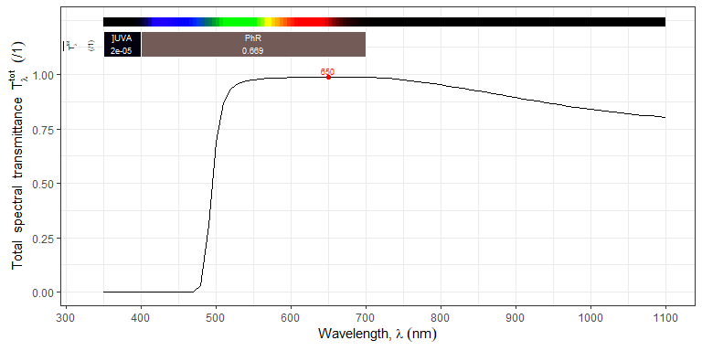

```r
autoplot(filters.mspct$MIDOPT_LP500)
```

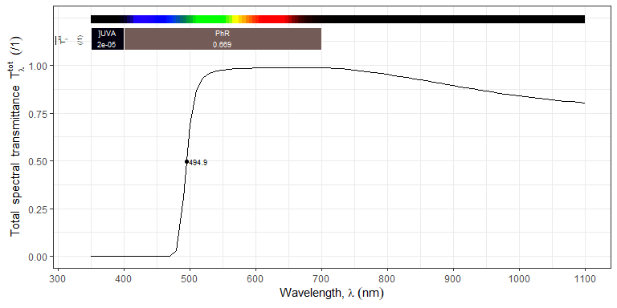

```r
autoplot(filters.mspct$MIDOPT_LP500,
         annotations = list(c("-", "peaks"), c("+", "wls")))
```

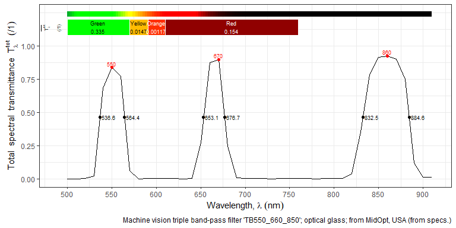

```r
autoplot(filters.mspct$MIDOPT_TB550_660_850,
         annotations = c("+", "title:none:none:what", "wls"),
         w.band = VIS_bands(),
         range = c(500, 910),
         span = 11)
```

To graphically compare filters, we can pass a collection of spectral objects, such as subset of `filters.mspct`.

```
## Discarding heterogeous 'filter.descriptor' attributes!!
```

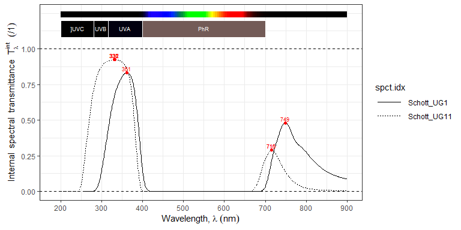

```r
autoplot(filters.mspct[c("Schott_UG1", "Schott_UG11")],
         range = c(200, 900),
         annotations = c("+", "boundaries"),
         span = 11)
```

To graphically compare filter thicknesses we can pass a collection of spectral objects.

```
## Discarding heterogeous 'filter.descriptor' attributes!!
```

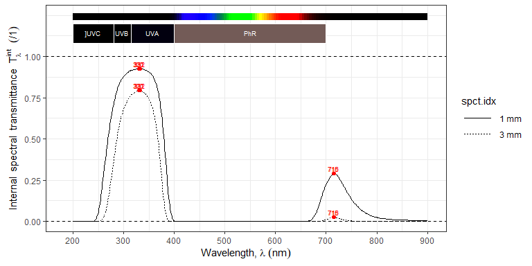

```r
thin_and_thick.mspct <-
  filter_mspct(list("1 mm" = filters.mspct$Schott_UG11,
                    "3 mm" = convertThickness(filters.mspct$Schott_UG11,
                                              thickness = 3e-3)))
autoplot(thin_and_thick.mspct,
         range = c(200, 900),
         annotations = c("+", "boundaries"),
         span = 101)
```

To graphically assess filter stacks with air gaps.

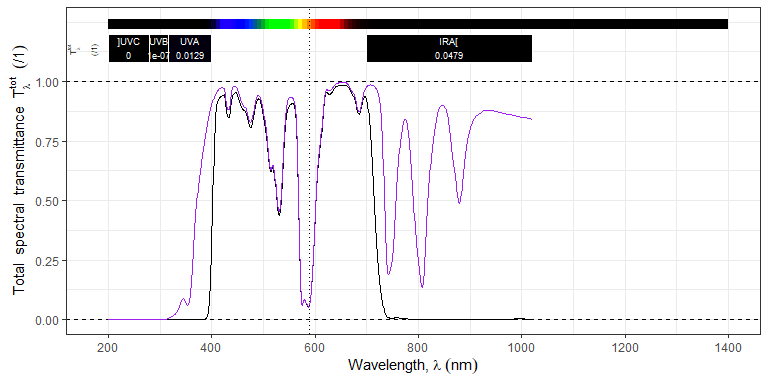

```r
stack.spct <- filters.mspct$Haida_Clear_Night_NanoPro_1.6mm_52mm * filters.mspct$Firecrest_UVIR_Cut_0.96mm_52mm

autoplot(stack.spct,
         range = c(NA, 1400),
         w.band = c(UV_bands(), IR_bands("CIE")),
         annotations = list(c("+", "boundaries"), c("-", "peaks")),
         span = 21) +
  geom_line(data = filters.mspct$Haida_Clear_Night_NanoPro_1.6mm_52mm, colour = "purple") +
  geom_vline(xintercept = c(589, 589.6), linetype = "dotted") # Na emission lines
```

Package ‘ggspectra’ also defines specializations of method `ggplot()` for spectra that automatically maps the $x$ and $y$ *aesthetics*.

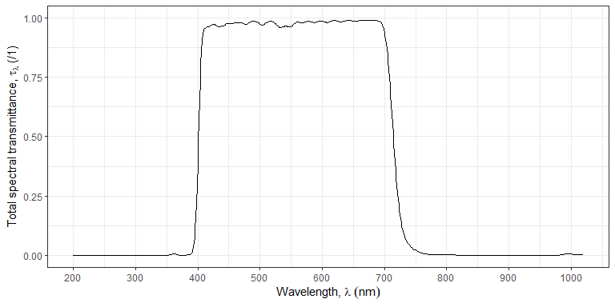

```r
ggplot(filters.mspct$Firecrest_UVIR_Cut_0.96mm_52mm) +
  geom_line() +
  scale_x_wl_continuous() +
  scale_y_Tfr_total_continuous()
```

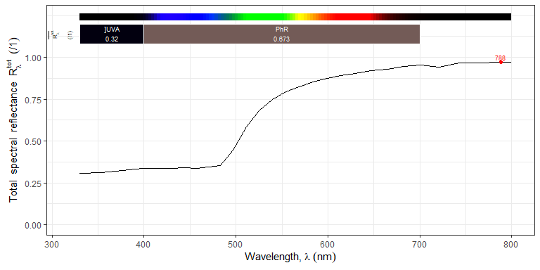

```r
autoplot(metals.mspct$gold, range = c(NA, 800))
```

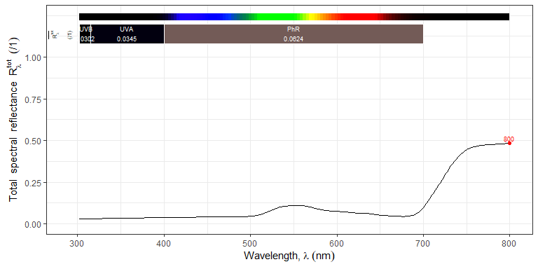

```r
autoplot(materials.mspct$grass, range = c(NA, 800))
```

## Calculating summaries

Here we use waveband definitions from package ‘photobiologyWavebands’ and summary functions from package ‘photobiology’.

```r
transmittance(filters.mspct$Firecrest_UVIR_Cut_0.96mm_52mm, UVA())
```

```
## Tfr(wl)_UVA.ISO
##      0.01554623
## attr(,"Tfr.type")
## [1] "total"
## attr(,"radiation.unit")
## [1] "transmittance average"
```

```r
absorbance(filters.mspct$Firecrest_UVIR_Cut_0.96mm_52mm, list(UVA(), NIR()))
```

```
##  A(wl)_UVA.ISO A(wl)_NIR.ISO[
##       2.941898       2.898525
## attr(,"Tfr.type")
## [1] "total"
## attr(,"radiation.unit")
## [1] "absorbance average"
```

```r
transmittance(filters.mspct[grep("UG", names(filters.mspct))],
              list(UVB(), UVA()))
```

```
## # A tibble: 5 × 3
##   spct.idx    `Tfr(wl)_UVB.ISO` `Tfr(wl)_UVA.ISO`
##   <fct>                   <dbl>             <dbl>
## 1 Schott_UG1             0.153              0.659
## 2 Schott_UG11            0.851              0.694
## 3 Schott_UG2A            0.0472             0.660
## 4 Schott_UG5             0.957              0.924
## 5 UQG_UG1_2mm            0.128              0.516
```

```r
reflectance(metals.mspct, w.band = VIS_bands())
```

```
## # A tibble: 12 × 7
##    spct.idx        `Rfr(wl)_Purple.ISO` `Rfr(wl)_Blue.ISO` `Rfr(wl)_Green.ISO`
##    <fct>                          <dbl>              <dbl>               <dbl>
##  1 aluminum                       0.843              0.865               0.866
##  2 copper                         0.276              0.382               0.476
##  3 gold                           0.333              0.366               0.702
##  4 molybdenum                     0.444              0.500               0.508
##  5 nickel                         0.445              0.523               0.563
##  6 platinum                       0.612              0.666               0.715
##  7 silver                         0.753              0.851               0.899
##  8 stainless_steel                0.526              0.579               0.603
##  9 tantalum                       0.411              0.403               0.389
## 10 tin                            0.701              0.797               0.822
## 11 titanium                       0.166              0.202               0.222
## 12 vanadium                       0.447              0.472               0.471
## # ℹ 3 more variables: `Rfr(wl)_Yellow.ISO` <dbl>, `Rfr(wl)_Orange.ISO` <dbl>,
## #   `Rfr(wl)_Red.ISO` <dbl>
```

## Using the data in other contexts

As `filter_mspct` is a class derived from `list`, and `filter_spct` is derived from `tibble::tible` which is a mostly compatible reimplementation of `data.frame` the data can be used very easily with any R function.

```r
head(as.data.frame(filters.mspct$Schott_UG11))
```

```
##   w.length   Tfr
## 1      200 1e-05
## 2      204 1e-05
## 3      207 1e-05
## 4      208 1e-05
## 5      209 1e-05
## 6      210 1e-05
```

Of course `attach` and `with` also work as expected.

```r
attach(filters.mspct)
transmittance(Schott_UG11, UVA())
```

```
## Tfr(wl)_UVA.ISO
##       0.6942081
## attr(,"Tfr.type")
## [1] "internal"
## attr(,"radiation.unit")
## [1] "transmittance average"
```

```r
detach(filters.mspct)
```

```r
attach(filters.mspct)
with(Schott_UG11, range(w.length))
```

```
## [1]  200 5200
```

```r
detach(filters.mspct)
```

```r
with(filters.mspct, transmittance(Schott_UG11, UVA()))
```

```
## Tfr(wl)_UVA.ISO
##       0.6942081
## attr(,"Tfr.type")
## [1] "internal"
## attr(,"radiation.unit")
## [1] "transmittance average"
```